# Manejo de Datos Faltantes

Implementación práctica de la Clase 10

Nicolás Sidicaro

2025-09-19

# Introducción

Como muchas partes requieren temas que todavía no vimos (test, visualizaciones y regresiones), este código queda de ejemplo para volver a ver más adelante con mayor profundidad.

## Objetivos del notebook

1. **Explorar** un dataset con valores faltantes
2. **Visualizar** patrones de datos faltantes
3. **Testear** si los datos son MCAR (Missing Completely at Random)
4. **Verificar** patrones MAR (Missing at Random)
5. **Implementar** diferentes métodos de imputación
6. **Comparar** resultados entre métodos

## Carga de librerías

```r
# Librerías principales
library(tidyverse)    # Manipulación de datos
library(VIM)          # Visualización de datos faltantes
library(naniar)       # Exploración de NAs
library(mice)         # Imputación múltiple
library(Hmisc)        # Herramientas estadísticas
library(kableExtra)   # Tablas mejoradas
library(patchwork)    # Combinar gráficos
library(ggpubr)       # Comparación de medias

# Configurar tema para gráficos
theme_set(theme_minimal())

# Semilla para reproducibilidad
set.seed(2025)
```

# 1. Creación y Exploración del Dataset

## 1.1 Generación de datos sintéticos

Vamos a crear un dataset similar a una encuesta de hogares con diferentes tipos de variables y patrones de datos faltantes que reflejen situaciones reales.

```r
# Número de observaciones
n <- 1000

# Crear dataset base completo
datos_completos <- tibble(
  id_hogar = 1:n,

  # Variables demográficas
  edad_jefe = round(rnorm(n, 45, 12)),
  educacion_anos = round(rnorm(n, 11, 3)),
  miembros_hogar = rpois(n, 3) + 1,
  region = sample(c("Norte", "Sur", "Centro", "Este", "Oeste"), n, replace = TRUE),
  tipo_vivienda = sample(c("Casa", "Departamento", "Otro"), n,
                        prob = c(0.6, 0.35, 0.05), replace = TRUE),

  # Variables económicas (con correlación realista)
  ingreso_laboral = exp(8 + 0.08 * educacion_anos + rnorm(n, 0, 0.5)) * 1000,
  horas_trabajadas = pmax(0, round(rnorm(n, 40, 10))),
  tiene_obra_social = rbinom(n, 1, 0.6),
  gasto_alimentos = exp(7.5 + 0.15 * log(miembros_hogar) + rnorm(n, 0, 0.3)) * 100,
  gasto_salud = exp(6 + 0.02 * edad_jefe + rnorm(n, 0, 0.4)) * 100
) %>%
  mutate(
    # Ajustes para valores realistas
    edad_jefe = pmax(18, pmin(85, edad_jefe)),
    educacion_anos = pmax(0, pmin(20, educacion_anos)),
    ingreso_total = ingreso_laboral + rnorm(n, 2000, 500),
    gasto_total = gasto_alimentos + gasto_salud + rnorm(n, 3000, 1000)
  )

# Guardar copia para comparación posterior
datos_originales <- datos_completos

# Mostrar primeras filas
head(datos_completos)
```

| id_hogar | edad_jefe | educacion_anos | miembros_hogar | region | tipo_vivienda | ingreso_laboral | horas_trabajadas | tiene_obra_social | gasto_alimentos | gasto_salud | ingreso_total | gasto_total |
| --- | --- | --- | --- | --- | --- | --- | --- | --- | --- | --- | --- | --- |
| 1 | 52 | 14 | 6 | Oeste | Casa | 8741733 | 47 | 1 | 189868.6 | 95547.08 | 8744774 | 288445.2 |
| 2 | 45 | 5 | 5 | Este | Casa | 5830276 | 28 | 1 | 253160.4 | 156385.41 | 5832585 | 412077.1 |
| 3 | 54 | 9 | 5 | Oeste | Casa | 6735650 | 33 | 0 | 216584.2 | 101112.89 | 6737367 | 319431.7 |
| 4 | 60 | 7 | 6 | Norte | Casa | 18904483 | 40 | 1 | 200979.1 | 150399.32 | 18905608 | 354596.6 |
| 5 | 49 | 9 | 3 | Centro | Departamento | 3199105 | 28 | 1 | 187374.2 | 99159.22 | 3200458 | 289896.8 |
| 6 | 43 | 9 | 2 | Centro | Departamento | 9923441 | 42 | 1 | 165743.4 | 82028.66 | 9925092 | 250160.9 |

## 1.2 Introducción de valores faltantes

Ahora introduciremos valores faltantes siguiendo los tres mecanismos principales:

- **MCAR**: Missing Completely at Random
- **MAR**: Missing at Random
- **MNAR**: Missing Not at Random

```r
datos_con_faltantes <- datos_completos %>%
  mutate(
    # MCAR: 10% faltante completamente al azar en horas_trabajadas
    horas_trabajadas = ifelse(runif(n) < 0.10, NA, horas_trabajadas),

    # MAR: Gasto en salud falta más en personas jóvenes
    prob_falta_salud = case_when(
      edad_jefe < 35 ~ 0.30,  # 30% faltante en jóvenes
      edad_jefe < 50 ~ 0.15,  # 15% en mediana edad
      TRUE ~ 0.05              # 5% en mayores
    ),
    gasto_salud = ifelse(runif(n) < prob_falta_salud, NA, gasto_salud),

    # MNAR: Ingresos altos tienen mayor probabilidad de no reportarse
    prob_falta_ingreso = case_when(
      ingreso_laboral > quantile(ingreso_laboral, 0.90) ~ 0.50,  # 50% en top 10%
      ingreso_laboral > quantile(ingreso_laboral, 0.75) ~ 0.30,  # 30% en Q4
      ingreso_laboral > quantile(ingreso_laboral, 0.50) ~ 0.15,  # 15% en Q3
      TRUE ~ 0.05                                                 # 5% en Q1-Q2
    ),
    ingreso_laboral = ifelse(runif(n) < prob_falta_ingreso, NA, ingreso_laboral),

    # Propagar faltantes a ingreso_total
    ingreso_total = ifelse(is.na(ingreso_laboral), NA, ingreso_total)
  ) %>%
  select(-prob_falta_salud, -prob_falta_ingreso)

# Mostrar resumen
summary(datos_con_faltantes)
```

```
##     id_hogar        edad_jefe     educacion_anos  miembros_hogar
##  Min.   :   1.0   Min.   :18.00   Min.   : 2.00   Min.   : 1.000
##  1st Qu.: 250.8   1st Qu.:37.00   1st Qu.: 9.00   1st Qu.: 3.000
##  Median : 500.5   Median :45.00   Median :11.00   Median : 4.000
##  Mean   : 500.5   Mean   :45.08   Mean   :10.88   Mean   : 3.953
##  3rd Qu.: 750.2   3rd Qu.:53.00   3rd Qu.:13.00   3rd Qu.: 5.000
##  Max.   :1000.0   Max.   :84.00   Max.   :20.00   Max.   :11.000
##
##     region          tipo_vivienda      ingreso_laboral    horas_trabajadas
##  Length:1000        Length:1000        Min.   : 1096759   Min.   : 4.00
##  Class :character   Class :character   1st Qu.: 4730253   1st Qu.:33.00
##  Mode  :character   Mode  :character   Median : 6851450   Median :40.00
##                                        Mean   : 7605027   Mean   :40.43
##                                        3rd Qu.: 9247925   3rd Qu.:47.00
##                                        Max.   :27364927   Max.   :75.00
##                                        NA's   :154        NA's   :112
##  tiene_obra_social gasto_alimentos   gasto_salud     ingreso_total
##  Min.   :0.000     Min.   : 83544   Min.   : 24100   Min.   : 1098807
##  1st Qu.:0.000     1st Qu.:173865   1st Qu.: 72650   1st Qu.: 4731743
##  Median :1.000     Median :214781   Median :101404   Median : 6852898
##  Mean   :0.586     Mean   :226652   Mean   :112278   Mean   : 7607046
##  3rd Qu.:1.000     3rd Qu.:264479   3rd Qu.:139484   3rd Qu.: 9249614
##  Max.   :1.000     Max.   :503611   Max.   :388440   Max.   :27367037
##                                     NA's   :146      NA's   :154
##   gasto_total
##  Min.   :153656
##  1st Qu.:275671
##  Median :326439
##  Mean   :339800
##  3rd Qu.:391477
##  Max.   :698638
##
```

## 1.3 Resumen de datos faltantes

```r
# Calcular estadísticas de faltantes
resumen_faltantes <- datos_con_faltantes %>%
  miss_var_summary() %>%
  filter(n_miss > 0) %>%
  mutate(
    mecanismo_esperado = case_when(
      variable == "horas_trabajadas" ~ "MCAR",
      variable == "gasto_salud" ~ "MAR",
      variable %in% c("ingreso_laboral", "ingreso_total") ~ "MNAR"
    )
  )

# Mostrar tabla formateada
resumen_faltantes %>%
  kable(caption = "Resumen de valores faltantes por variable",
        col.names = c("Variable", "N Faltantes", "% Faltante", "Mecanismo Esperado")) %>%
  kable_styling(bootstrap_options = c("striped", "hover")) %>%
  row_spec(which(resumen_faltantes$pct_miss > 20), bold = TRUE, color = "red")
```

Resumen de valores faltantes por variable

| Variable | N Faltantes | % Faltante | Mecanismo Esperado |
| --- | --- | --- | --- |
| ingreso_laboral | 154 | 15.4 | MNAR |
| ingreso_total | 154 | 15.4 | MNAR |
| gasto_salud | 146 | 14.6 | MAR |
| horas_trabajadas | 112 | 11.2 | MCAR |

# 2. Visualización de Patrones de Datos Faltantes

La visualización es crucial para entender los patrones de datos faltantes antes de decidir una estrategia de imputación.

## 2.1 Vista general de faltantes

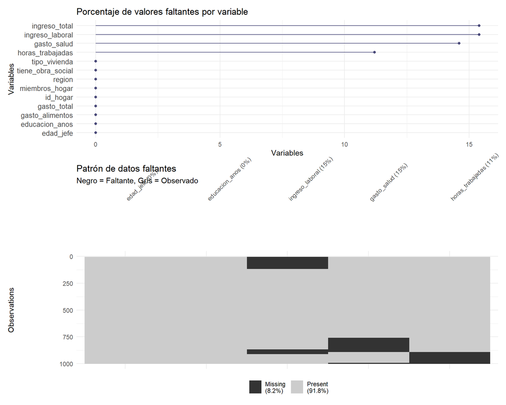

```r
# Gráfico de barras de porcentaje faltante
p1 <- gg_miss_var(datos_con_faltantes, show_pct = TRUE) +
  labs(title = "Porcentaje de valores faltantes por variable",
       y = "Variables") +
  theme(axis.text.y = element_text(size = 10))

# Patrón de datos faltantes (heatmap)
p2 <- vis_miss(datos_con_faltantes %>%
               select(edad_jefe, educacion_anos, ingreso_laboral,
                     gasto_salud, horas_trabajadas),
               cluster = TRUE) +
  labs(title = "Patrón de datos faltantes",
       subtitle = "Negro = Faltante, Gris = Observado")

# Combinar gráficos
p1 / p2
```

## 2.2 Análisis de co-ocurrencia

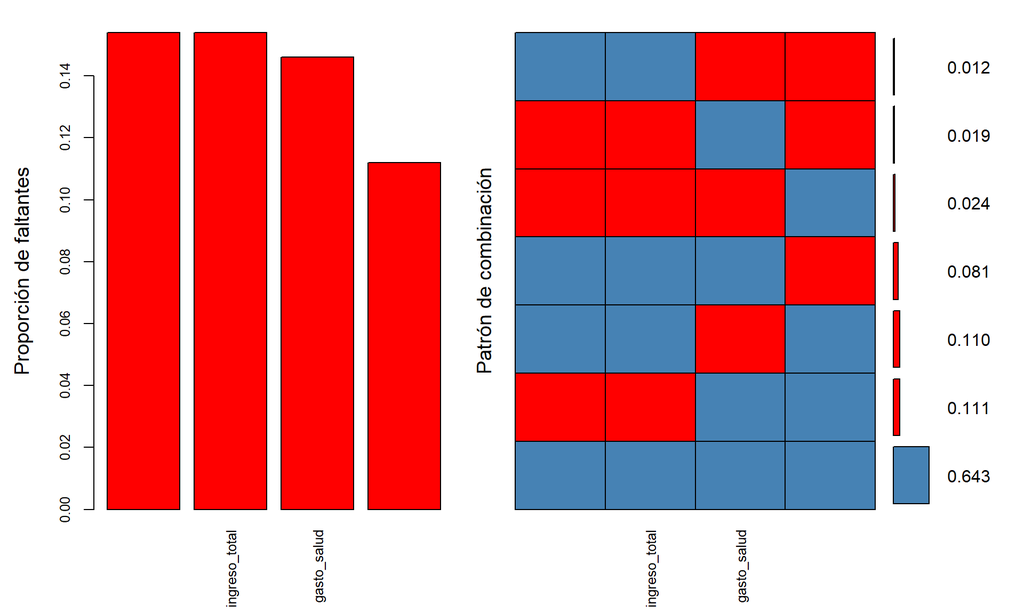

```
##
##  Variables sorted by number of missings:
##          Variable Count
##   ingreso_laboral 0.154
##     ingreso_total 0.154
##       gasto_salud 0.146
##  horas_trabajadas 0.112
```

```r
# Matriz de patrones usando VIM
variables_key <- c("ingreso_laboral", "ingreso_total", "gasto_salud", "horas_trabajadas")

aggr(datos_con_faltantes[, variables_key],
     col = c('steelblue', 'red'),
     numbers = TRUE,
     sortVars = TRUE,
     labels = variables_key,
     cex.axis = 0.8,
     gap = 3,
     ylab = c("Proporción de faltantes", "Patrón de combinación"))
```

## 2.3 Análisis de upset plot

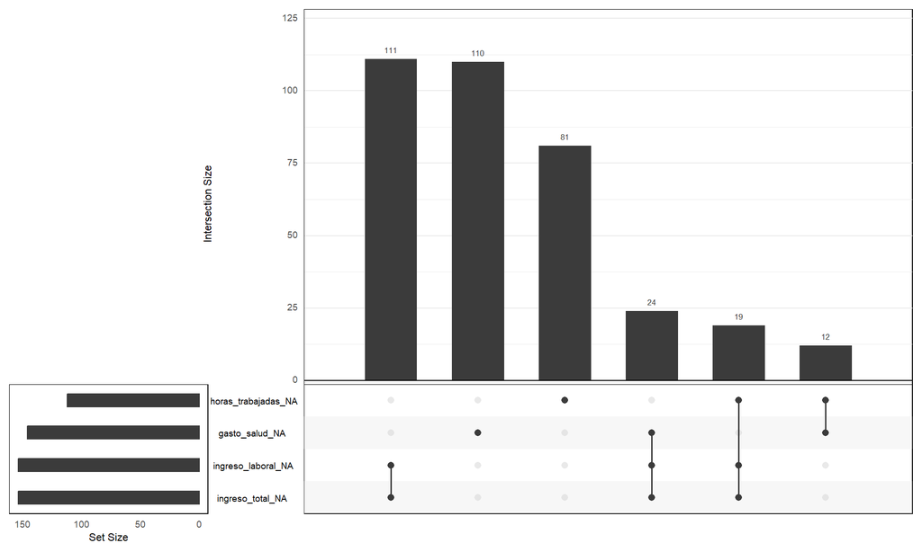

```r
# Upset plot para ver intersecciones de faltantes
gg_miss_upset(datos_con_faltantes %>%
              select(all_of(variables_key)),
              nsets = 4,
              nintersects = 10)
```

# 3. Test de MCAR (Missing Completely at Random)

## 3.1 Test de Little

El test de Little evalúa la hipótesis nula de que los datos son MCAR. Si rechazamos H0 (p < 0.05), los datos NO son MCAR.

Para leer sobre el test: https://medium.com/@tarangds/understanding-littles-mcar-test-a-key-tool-in-missing-data-analysis-47fd70698149

```r
# Preparar datos para el test
datos_para_test <- datos_con_faltantes %>%
  select(where(is.numeric)) %>%
  select(where(~any(is.na(.))))

# Realizar test de Little
test_mcar <- naniar::mcar_test(datos_para_test)

# Crear dataframe con resultados
resultados_mcar <- data.frame(
  Estadistico = round(test_mcar$statistic, 2),
  `Grados de libertad` = test_mcar$df,
  `P-value` = format(test_mcar$p.value, scientific = TRUE),
  Conclusion = ifelse(test_mcar$p.value < 0.05,
                      "Rechazamos H0: Datos NO son MCAR",
                      "No rechazamos H0: Datos podrían ser MCAR")
)

resultados_mcar %>%
  kable(caption = "Resultados del Test de Little para MCAR") %>%
  kable_styling(bootstrap_options = "striped", full_width = FALSE) %>%
  column_spec(4, bold = TRUE,
              color = ifelse(test_mcar$p.value < 0.05, "red", "green"))
```

Resultados del Test de Little para MCAR

| Estadistico | Grados.de.libertad | P.value | Conclusion |
| --- | --- | --- | --- |
| 8.25 | 12 | 7.649961e-01 | No rechazamos H0: Datos podrían ser MCAR |

## 3.2 Comparación de medias

Comparamos las características observables entre casos con y sin valores faltantes para cada variable.

```r
# Función para comparar medias
comparar_medias <- function(data, var_faltante, var_comparar) {
  con_dato <- data %>%
    filter(!is.na({{var_faltante}})) %>%
    pull({{var_comparar}})

  sin_dato <- data %>%
    filter(is.na({{var_faltante}})) %>%
    pull({{var_comparar}})

  if(length(sin_dato) > 0 && length(con_dato) > 0) {
    test <- t.test(con_dato, sin_dato)
    return(tibble(
      variable_faltante = deparse(substitute(var_faltante)),
      variable_comparada = deparse(substitute(var_comparar)),
      media_con_dato = mean(con_dato, na.rm = TRUE),
      media_sin_dato = mean(sin_dato, na.rm = TRUE),
      diferencia = mean(con_dato, na.rm = TRUE) - mean(sin_dato, na.rm = TRUE),
      p_value = test$p.value
    ))
  }
  return(NULL)
}

# Comparar para ingreso_laboral
comparaciones <- bind_rows(
  comparar_medias(datos_con_faltantes, ingreso_laboral, edad_jefe),
  comparar_medias(datos_con_faltantes, ingreso_laboral, educacion_anos),
  comparar_medias(datos_con_faltantes, gasto_salud, edad_jefe),
  comparar_medias(datos_con_faltantes, horas_trabajadas, educacion_anos)
)

comparaciones %>%
  mutate(across(where(is.numeric), ~round(., 3))) %>%
  mutate(significativo = ifelse(p_value < 0.05, "Sí", "No")) %>%
  kable(caption = "Comparación de medias: casos completos vs faltantes") %>%
  kable_styling(bootstrap_options = c("striped", "hover")) %>%
  row_spec(which(comparaciones$p_value < 0.05), bold = TRUE, color = "blue")
```

Comparación de medias: casos completos vs faltantes

| variable_faltante | variable_comparada | media_con_dato | media_sin_dato | diferencia | p_value | significativo |
| --- | --- | --- | --- | --- | --- | --- |
| var_faltante | var_comparar | 45.118 | 44.851 | 0.268 | 0.802 | No |
| var_faltante | var_comparar | 10.678 | 11.974 | -1.296 | 0.000 | Sí |
| var_faltante | var_comparar | 46.148 | 38.815 | 7.332 | 0.000 | Sí |
| var_faltante | var_comparar | 10.899 | 10.714 | 0.184 | 0.549 | No |

# 4. Verificación de MAR (Missing at Random)

## 4.1 Modelo predictivo de faltantes

Si podemos predecir los valores faltantes usando variables observadas, esto sugiere un patrón MAR.

```r
# Crear indicadores de faltantes
datos_indicadores <- datos_con_faltantes %>%
  mutate(
    missing_ingreso = as.numeric(is.na(ingreso_laboral)),
    missing_salud = as.numeric(is.na(gasto_salud)),
    missing_horas = as.numeric(is.na(horas_trabajadas))
  )

# Modelo logístico para predecir ingreso faltante
modelo_ingreso <- glm(missing_ingreso ~ edad_jefe + educacion_anos +
                      region + tipo_vivienda + miembros_hogar,
                      data = datos_indicadores,
                      family = binomial())

# Modelo para gasto_salud faltante
modelo_salud <- glm(missing_salud ~ edad_jefe + educacion_anos +
                    region + miembros_hogar,
                    data = datos_indicadores,
                    family = binomial())

# Crear tabla de resumen
resumen_modelos <- bind_rows(
  broom::tidy(modelo_ingreso) %>% mutate(modelo = "Ingreso faltante"),
  broom::tidy(modelo_salud) %>% mutate(modelo = "Gasto salud faltante")
) %>%
  filter(p.value < 0.1) %>%
  mutate(across(where(is.numeric), ~round(., 4)))

resumen_modelos %>%
  select(modelo, term, estimate, std.error, p.value) %>%
  kable(caption = "Variables significativas para predecir faltantes (p < 0.1)") %>%
  kable_styling(bootstrap_options = c("striped", "hover")) %>%
  row_spec(which(resumen_modelos$p.value < 0.05), bold = TRUE)
```

Variables significativas para predecir faltantes (p < 0.1)

| modelo | term | estimate | std.error | p.value |
| --- | --- | --- | --- | --- |
| Ingreso faltante | (Intercept) | -3.1105 | 0.5866 | 0.000 |
| Ingreso faltante | educacion_anos | 0.1372 | 0.0295 | 0.000 |
| Ingreso faltante | regionEste | 0.4569 | 0.2728 | 0.094 |
| Gasto salud faltante | (Intercept) | 1.1675 | 0.5626 | 0.038 |
| Gasto salud faltante | edad_jefe | -0.0574 | 0.0085 | 0.000 |

## 4.2 Visualización de relaciones MAR

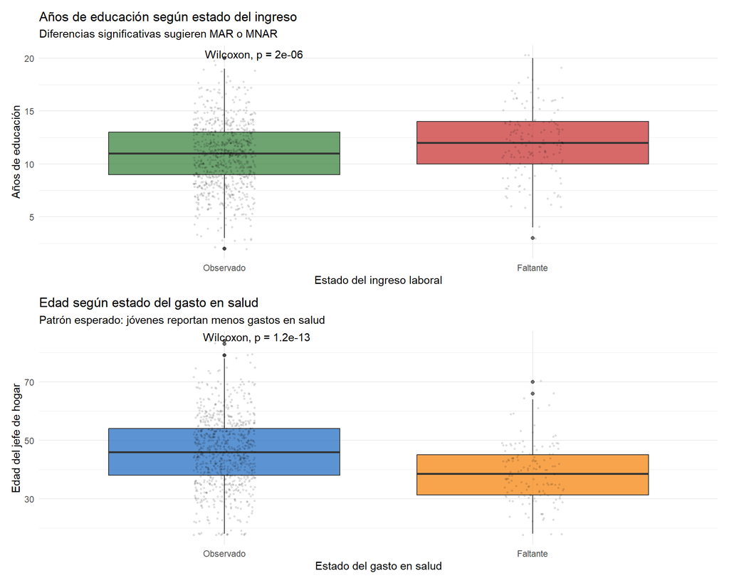

```r
# Boxplot: Educación según estado de ingreso
p1 <- ggplot(datos_indicadores,
       aes(x = factor(missing_ingreso, labels = c("Observado", "Faltante")),
           y = educacion_anos,
           fill = factor(missing_ingreso))) +
  geom_boxplot(alpha = 0.7) +
  geom_jitter(width = 0.1, alpha = 0.1, size = 0.5) +
  labs(title = "Años de educación según estado del ingreso",
       subtitle = "Diferencias significativas sugieren MAR o MNAR",
       x = "Estado del ingreso laboral",
       y = "Años de educación") +
  scale_fill_manual(values = c("#2E7D32", "#C62828"), guide = "none") +
  stat_compare_means()

# Boxplot: Edad según estado de gasto_salud
p2 <- ggplot(datos_indicadores,
       aes(x = factor(missing_salud, labels = c("Observado", "Faltante")),
           y = edad_jefe,
           fill = factor(missing_salud))) +
  geom_boxplot(alpha = 0.7) +
  geom_jitter(width = 0.1, alpha = 0.1, size = 0.5) +
  labs(title = "Edad según estado del gasto en salud",
       subtitle = "Patrón esperado: jóvenes reportan menos gastos en salud",
       x = "Estado del gasto en salud",
       y = "Edad del jefe de hogar") +
  scale_fill_manual(values = c("#1565C0", "#F57C00"), guide = "none") +
  stat_compare_means()

p1 / p2
```

# 5. Métodos de Imputación

Implementaremos y compararemos diferentes métodos de imputación.

## 5.1 Imputación simple (media)

```r
# Imputación con media
datos_imp_media <- datos_con_faltantes %>%
  mutate(across(where(is.numeric),
                ~ifelse(is.na(.), mean(., na.rm = TRUE), .),
                .names = "{.col}_media"))

# Comparar estadísticas
comparacion_media <- tibble(
  Variable = "ingreso_laboral",
  `Original (media)` = mean(datos_originales$ingreso_laboral),
  `Original (sd)` = sd(datos_originales$ingreso_laboral),
  `Solo observados (media)` = mean(datos_con_faltantes$ingreso_laboral, na.rm = TRUE),
  `Solo observados (sd)` = sd(datos_con_faltantes$ingreso_laboral, na.rm = TRUE),
  `Imp. media (media)` = mean(datos_imp_media$ingreso_laboral_media),
  `Imp. media (sd)` = sd(datos_imp_media$ingreso_laboral_media)
) %>%
  mutate(across(where(is.numeric), ~round(., 0)))

comparacion_media %>%
  kable(caption = "Impacto de imputación con media en estadísticas") %>%
  kable_styling(bootstrap_options = "striped", full_width = FALSE)
```

Impacto de imputación con media en estadísticas

| Variable | Original (media) | Original (sd) | Solo observados (media) | Solo observados (sd) | Imp. media (media) | Imp. media (sd) |
| --- | --- | --- | --- | --- | --- | --- |
| ingreso_laboral | 8395204 | 4858785 | 7605027 | 4010725 | 7605027 | 3688659 |

## 5.2 Imputación por regresión

```r
# Modelo de regresión para imputar ingreso
modelo_imp <- lm(ingreso_laboral ~ edad_jefe + educacion_anos +
                tipo_vivienda + miembros_hogar,
                data = datos_con_faltantes)

# Predecir valores faltantes
predicciones <- predict(modelo_imp, newdata = datos_con_faltantes)

datos_imp_reg <- datos_con_faltantes %>%
  mutate(ingreso_laboral_reg = coalesce(ingreso_laboral, predicciones))

# R-cuadrado del modelo
r2 <- summary(modelo_imp)$r.squared
cat("R² del modelo de imputación:", round(r2, 3))
```

```
## R² del modelo de imputación: 0.143
```

## 5.3 Imputación múltiple (MICE)

```r
# Seleccionar variables para imputación
vars_mice <- datos_con_faltantes %>%
  select(edad_jefe, educacion_anos, miembros_hogar,
         ingreso_laboral, gasto_salud, horas_trabajadas)

# Configurar y ejecutar MICE
mice_imp <- mice(vars_mice,
                m = 5,            # 5 imputaciones
                method = 'pmm',   # Predictive mean matching
                seed = 2025,
                printFlag = FALSE)

# Ver métodos utilizados
print(mice_imp$method)
```

```
##        edad_jefe   educacion_anos   miembros_hogar  ingreso_laboral
##               ""               ""               ""            "pmm"
##      gasto_salud horas_trabajadas
##            "pmm"            "pmm"
```

```r
# Extraer primera imputación completa
datos_imp_mice <- complete(mice_imp, 1)
```

## 5.4 Diagnóstico de convergencia

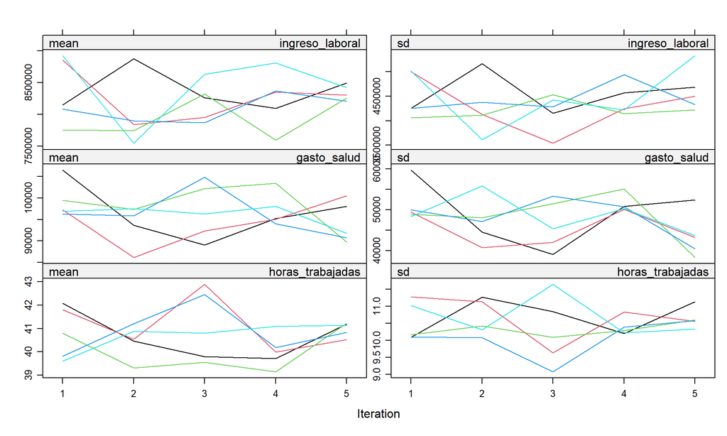

```r
# Gráfico de convergencia
plot(mice_imp, layout = c(2, 3))
```

## 5.5 Comparación visual de métodos

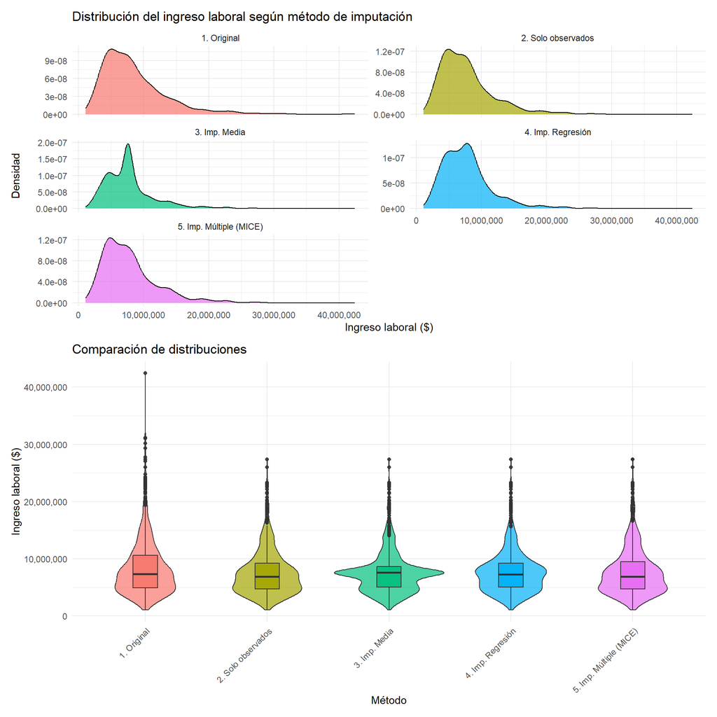

```r
# Preparar datos para comparación
comparacion_dist <- bind_rows(
  datos_originales %>%
    select(ingreso_laboral) %>%
    mutate(metodo = "1. Original"),

  datos_con_faltantes %>%
    select(ingreso_laboral) %>%
    filter(!is.na(ingreso_laboral)) %>%
    mutate(metodo = "2. Solo observados"),

  datos_imp_media %>%
    select(ingreso_laboral = ingreso_laboral_media) %>%
    mutate(metodo = "3. Imp. Media"),

  datos_imp_reg %>%
    select(ingreso_laboral = ingreso_laboral_reg) %>%
    mutate(metodo = "4. Imp. Regresión"),

  datos_imp_mice %>%
    select(ingreso_laboral) %>%
    mutate(metodo = "5. Imp. Múltiple (MICE)")
)

# Gráfico de densidades
p1 <- ggplot(comparacion_dist, aes(x = ingreso_laboral, fill = metodo)) +
  geom_density(alpha = 0.7) +
  facet_wrap(~metodo, ncol = 2, scales = "free_y") +
  labs(title = "Distribución del ingreso laboral según método de imputación",
       x = "Ingreso laboral ($)",
       y = "Densidad") +
  scale_x_continuous(labels = scales::comma) +
  theme(legend.position = "none")

# Gráfico de violín
p2 <- ggplot(comparacion_dist, aes(x = metodo, y = ingreso_laboral, fill = metodo)) +
  geom_violin(alpha = 0.7) +
  geom_boxplot(width = 0.2, alpha = 0.9) +
  labs(title = "Comparación de distribuciones",
       x = "Método",
       y = "Ingreso laboral ($)") +
  scale_y_continuous(labels = scales::comma) +
  theme(legend.position = "none",
        axis.text.x = element_text(angle = 45, hjust = 1))

p1 / p2
```

## 5.6 Tabla comparativa de resultados

```r
# Calcular estadísticas para cada método
resumen_metodos <- comparacion_dist %>%
  group_by(metodo) %>%
  summarise(
    n = n(),
    media = mean(ingreso_laboral, na.rm = TRUE),
    mediana = median(ingreso_laboral, na.rm = TRUE),
    sd = sd(ingreso_laboral, na.rm = TRUE),
    cv = sd/media,
    p10 = quantile(ingreso_laboral, 0.10, na.rm = TRUE),
    p90 = quantile(ingreso_laboral, 0.90, na.rm = TRUE),
    rango_intercuartil = IQR(ingreso_laboral, na.rm = TRUE),
    .groups = "drop"
  ) %>%
  mutate(across(where(is.numeric), ~round(., 0)))

resumen_metodos %>%
  kable(caption = "Estadísticas resumen por método de imputación",
        col.names = c("Método", "N", "Media", "Mediana", "SD", "CV",
                     "P10", "P90", "IQR")) %>%
  kable_styling(bootstrap_options = c("striped", "hover", "condensed")) %>%
  row_spec(1, bold = TRUE, color = "white", background = "#2196F3") %>%
  row_spec(5, bold = TRUE, color = "white", background = "#4CAF50")
```

Estadísticas resumen por método de imputación

Método

N

Media

Mediana

SD

CV

P10

P90

IQR

1. Original

1000

8395204

7360414

4858785

1

3626167

14502317

5668721

2. Solo observados

846

7605027

6851450

4010725

1

3473479

13245856

4517672

3. Imp. Media

1000

7605027

7605027

3688659

0

3673142

12339210

3589487

4. Imp. Regresión

1000

7701782

7285456

3745012

0

3673142

12339210

4226295

5. Imp. Múltiple (MICE)

1000

7742000

6909275

4131484

1

3523683

13492848

4703800

# 6. Análisis de Sensibilidad

## 6.1 Variando el número de imputaciones

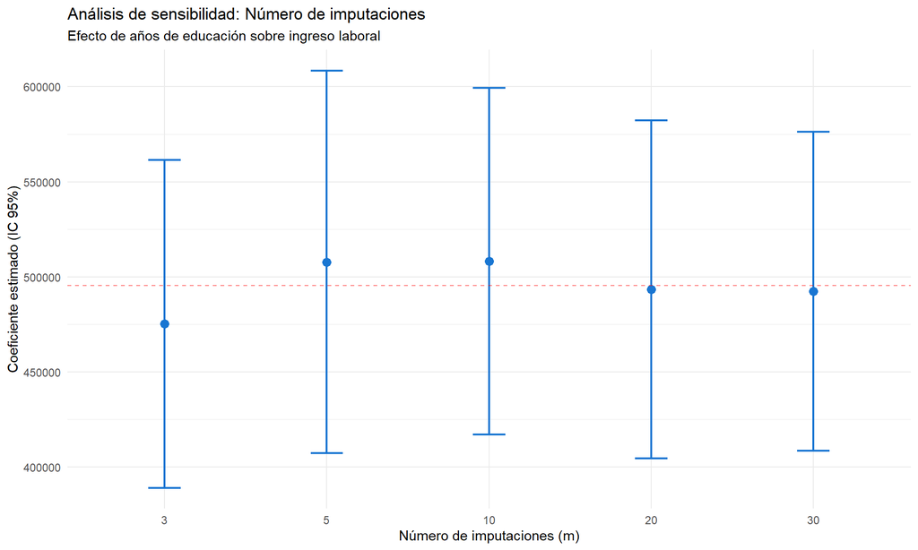

```r
# Función para analizar con diferentes m
analizar_m <- function(m_value, data) {
  mice_temp <- mice(data, m = m_value, method = 'pmm',
                   seed = 2025, printFlag = FALSE)

  # Modelo en cada dataset imputado
  fits <- with(mice_temp, lm(ingreso_laboral ~ educacion_anos + edad_jefe))

  # Combinar resultados
  pooled <- pool(fits)
  summ <- summary(pooled)

  # Extraer coeficiente de educación
  edu_coef <- summ[summ$term == "educacion_anos", ]

  return(tibble(
    m = m_value,
    coeficiente = edu_coef$estimate,
    error_std = edu_coef$std.error,
    ci_lower = edu_coef$estimate - 1.96 * edu_coef$std.error,
    ci_upper = edu_coef$estimate + 1.96 * edu_coef$std.error
  ))
}

# Analizar con diferentes valores de m
valores_m <- c(3, 5, 10, 20, 30)
resultados_m <- map_df(valores_m, ~analizar_m(.x, vars_mice))

# Visualizar
ggplot(resultados_m, aes(x = factor(m), y = coeficiente)) +
  geom_point(size = 3, color = "#1976D2") +
  geom_errorbar(aes(ymin = ci_lower, ymax = ci_upper),
                width = 0.2, color = "#1976D2", size = 0.8) +
  geom_hline(yintercept = mean(resultados_m$coeficiente),
             linetype = "dashed", color = "red", alpha = 0.5) +
  labs(title = "Análisis de sensibilidad: Número de imputaciones",
       subtitle = "Efecto de años de educación sobre ingreso laboral",
       x = "Número de imputaciones (m)",
       y = "Coeficiente estimado (IC 95%)") +
  theme_minimal()
```